# Assignment 1 - The tidyverse

VISHAL TRIPATHI

September 27, 2022 | 14:03:14 | CEST

```r
options(scipen=999)

# LOAD THE PACKAGES YOU ARE USING IN THIS CODE CHUNK library(nameofpackage)
library(tidyverse)
library(magrittr)
library(legislatoR)
library(tibble)
library(ggplot2)
library(stringr)
library(DescTools)
```

### Getting started with the Comparative Legislators Database

The Comparative Legislators Database (CLD) includes political, sociodemographic, career, online presence, public attention, and visual information for over 45,000 contemporary and historical politicians from ten countries (see the [corresponding article](https://www.cambridge.org/core/journals/british-journal-of-political-science/article/comparative-legislators-database/D28BB58A8B2C08C8593DB741F42C18B2) for more information). It can be accessed via `legislatoR` - an R package that is available on both [CRAN](https://cran.r-project.org/web/packages/legislatoR/index.html) and [GitHub](https://github.com/saschagobel/legislatoR).

Before you start with the following tasks, skim the tutorial to make yourself familiar with the database. You find it [here](https://cran.r-project.org/web/packages/legislatoR/vignettes/legislatoR.html).

For the following tasks, you will work with ONE of the legislatures. The legislature you’ll work with depends on your first name:

| Your first name starts with… | Legislature | Code |
| --- | --- | --- |
| A-C | Austrian Nationalrat | `aut` |
| D-F | Canadian House of Commons | `can` |
| G-I | Czech Poslanecka Snemovna | `cze` |
| J-L | Spanish Congreso de los Diputados | `esp` |
| M-O | French Assemblée | `fra` |
| P-R | German Bundestag | `deu` |
| S-U | Irish Dail | `irl` |
| V-X | UK House of Commons | `gbr` |
| Y-Z | US House of Representatives | `usa_house` |

The following tasks will be based on data from the `core` and `political` tables of the database.

### Task 1 - Descriptives [8 points in total]

1. What’s the overall share of male legislators in the entire dataset? [1 point]

```r
gbr_core <- get_core(legislature = "gbr")

gbr_core %>%
  dplyr::count(sex)
```

| sex | n |
| --- | --- |
| female | 552 |
| male | 11049 |
| NA | 1613 |

```r
# Assuming that all NA values of sex implies "other" gender, we calc the male proportion
male_prop <- ((11049/(552+11049+1613))*100)
paste("The overall share of male legislators in the dataset is:", round(male_prop,2), "%")
```

```
[1] "The overall share of male legislators in the dataset is: 83.62 %"
```

2. How many (both in absolute and relative terms) legislators died in the same place they were born in? [1 point]

```r
#separating the latitudes and longitudes of both birth and death places, then counting exact matches
gbr_core %>%
  separate(col=birthplace, c("birth_lat", "birth_long"), sep=",") %>%
  separate(col=deathplace, c("death_lat", "death_long"), sep=",") %>%
  mutate(bd_same = ifelse((birth_lat == death_lat & birth_long == death_long), 1, 0)) %>%
  count(bd_same)
```

| bd_same | n |
| --- | --- |
| 0 | 1365 |
| 1 | 188 |
| NA | 11661 |

```r
bd_rel <- (188*100)/(1365+188+11661)

paste("The no. of who legislators died in the same place they were born in - in ABSOLUTE terms:", 188)
```

```
[1] "The no. of who legislators died in the same place they were born in - in ABSOLUTE terms: 188"
```

```r
paste("The no. of who legislators died in the same place they were born in - in RELATIVE terms:", round(bd_rel,2))
```

```
[1] "The no. of who legislators died in the same place they were born in - in RELATIVE terms: 1.42"
```

3. Create a new variable `age_at_death` that reports the age at which legislators died. Then, plot the distribution of that variable for the entire dataset. [2 points]

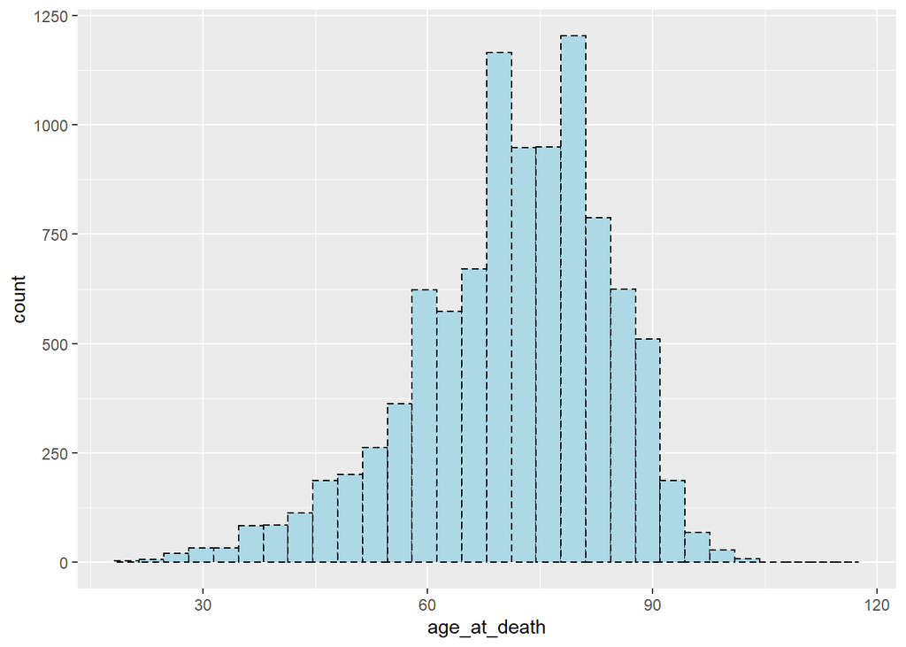

```r
#calculating difference in birth and death dates in days, dividing by 365 and then rounding off

gbr_core%>%
  mutate(age_at_death = round((as.numeric(difftime(as.Date(death), as.Date(birth), unit="days"))/365),0)) %>%
  ggplot2::ggplot(aes(x=age_at_death)) +
  geom_histogram(color="black", fill="lightblue",
                 linetype="dashed")
```

4. What is the most frequent birthday in your sample (e.g., “January 15”)? [2 points]

```r
# Modifying th year of each birth date to 2022 to compare frequency

gbr_core %>%
 mutate(mod_birth = update(birth, year = 2022)) %>%
  count(mod_birth)
```

| mod_birth | n |
| --- | --- |
| 2022-01-01 | 2650 |
| 2022-01-02 | 21 |
| 2022-01-03 | 29 |
| 2022-01-04 | 21 |
| 2022-01-05 | 23 |
| 2022-01-06 | 20 |
| 2022-01-07 | 18 |
| 2022-01-08 | 29 |
| 2022-01-09 | 17 |
| 2022-01-10 | 22 |

[output cut: 356 more lines]

```r
paste("The most frequent birthday is 1st of January")
```

```
[1] "The most frequent birthday is 1st of January"
```

5. Generate a table that provides the 5 legislators with the longest names (in terms of number of characters, ignoring whitespace). [2 points]

```r
new_df <- gbr_core %>%
 mutate(name_mod1 = str_replace_all(name," ","" )) %>%  # removing white spaces
  mutate(name_mod1 = str_replace_all(name_mod1,"-","" ))%>% # removing dashes
   mutate(name_mod1 = str_replace_all(name_mod1,",","" )) # removing commas

new_df %>%
  mutate(name_length = nchar(name_mod1)) %>% #storing length of name
   arrange(desc(name_length)) %>% #arranging in descending order
    top_n(5, name_length) %>% #printing top 5 rows
     select(name, name_mod1)
```

| name | name_mod1 |
| --- | --- |
| Richard Plantagenet Temple-Nugent-Brydges-Chandos-Grenville, 3rd Duke of Buckingham and Chandos | RichardPlantagenetTempleNugentBrydgesChandosGrenville3rdDukeofBuckinghamandChandos |
| Charles Robert Wynn-Carington, 1st Marquess of Lincolnshire | CharlesRobertWynnCarington1stMarquessofLincolnshire |
| Henry Douglas-Scott-Montagu, 1st Baron Montagu of Beaulieu | HenryDouglasScottMontagu1stBaronMontaguofBeaulieu |
| Chichester Parkinson-Fortescue, 1st Baron Carlingford | ChichesterParkinsonFortescue1stBaronCarlingford |
| Wellington Stapleton-Cotton, 2nd Viscount Combermere | WellingtonStapletonCotton2ndViscountCombermere |

### Task 2 - Exploring trends in the data [8 points in total]

1. Using data from all sessions, provide a plot that shows the share of male legislators by session! [3 points]

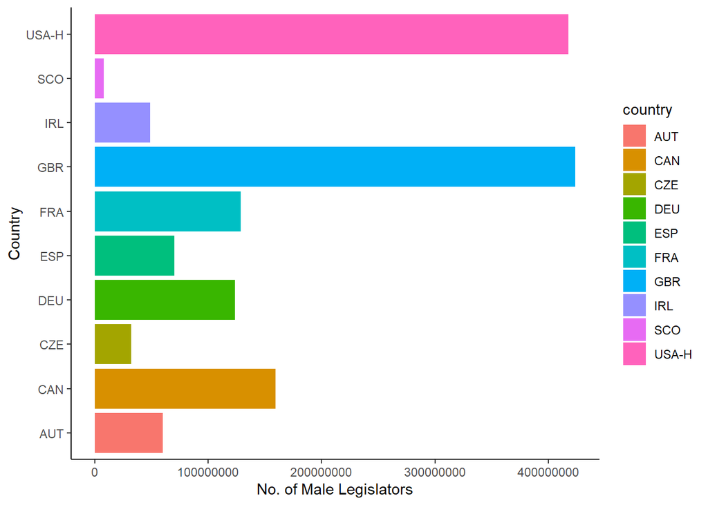

```r
# importing data from each session and storing in different data frames
gbr_core <- get_core(legislature = "gbr")
aut_core <- get_core(legislature = "aut")
can_core <- get_core(legislature = "can")
cze_core <- get_core(legislature = "cze")
fra_core <- get_core(legislature = "fra")
deu_core <- get_core(legislature = "deu")
irl_core <- get_core(legislature = "irl")
sco_core <- get_core(legislature = "sco")
esp_core <- get_core(legislature = "esp")
usa_core <- get_core(legislature = "usa_house")

#combining all data frames in a list
df_list_core <- list(gbr_core, aut_core, can_core, cze_core, fra_core, deu_core, irl_core, sco_core, esp_core, usa_core)

#joining all data frames in the list to make a master data frame
master_data_core <- df_list_core %>%
  reduce(full_join)

#filtering legislators by country and sex in master data frame
master_male <- master_data_core %>%
  group_by(country) %>%
   filter(sex == "male")

#plotting a bar chart to show distribution of male legislators across countries
ggplot(master_male, aes(x = country, y = length(sex), fill = country)) +
    geom_bar(stat = "identity") +
    labs(y= "No. of Male Legislators", x = "Country") +
    coord_flip() +
    theme_classic()
```

2. Explore another relation of variables in the dataset. Your analysis should (i) use data from both the `core` and the `political` table and (ii) feature data from several sessions. Also, offer a brief description and interpretation of your findings! [5 points]

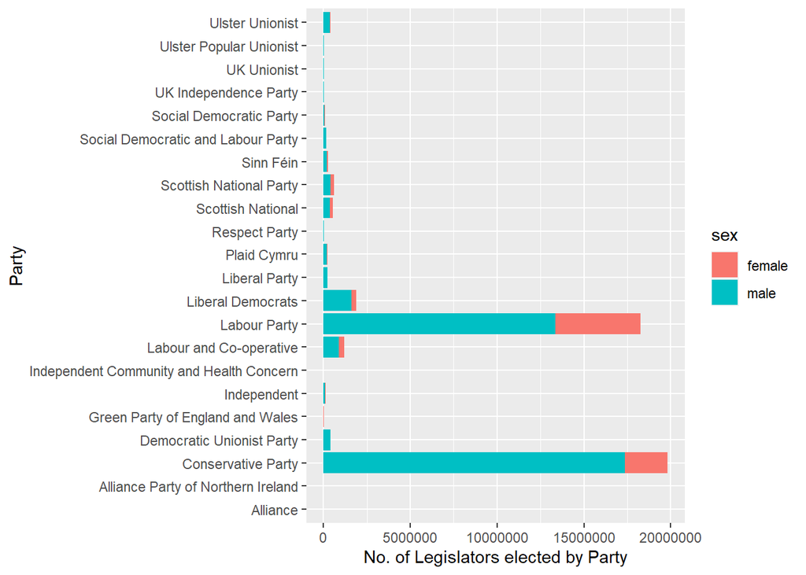

```r
# YOUR CODE HERE

# importing data from each session and storing in different data frames
gbr_pol <- get_political(legislature = "gbr")

#merging both pol and core data frames of Great Britain by pageID

total_gbr <- merge(gbr_core, gbr_pol, by= "pageid", all=TRUE)

total_gbr %>%
    filter(session_start > '1979-05-04') %>%
    ggplot(aes(x = party, y = length(sex), fill = sex)) +
    geom_bar(stat = "identity") +
    labs(y= "No. of Legislators elected by Party", x = "Party") +
    coord_flip()
```

In this graph, we are analysing the number of male and females legislators elcted by each party in United Kingdom since the election of their first female Prime Minister, Ms. Margaret Thatcher on 4th of May 1979. The trend shows that despite Ms. Thatcher belonging to the Conservative Party, it is the Labour Party which has elected more female legislators to the Parliament.